# Exploring the airway dataset

Emma Gail

2024-09-04

# Introduction

This tutorial is to demonstrate basic concepts in the downstream analysis of RNA-seq data (after quantification of gene expression) in R using the `airway` dataset. The `airway` dataset examines the transcriptional response of human airway smooth muscle cells to dexamethasone treatment.

# **Step 1:** Set up your enviornment

## Install libraries

In order to install the packages and data needed for this vignette, you will need to download the Bioconductor installation manager from CRAN.

```r
# Install Bioconductor manager (for installing packages)
if (!requireNamespace("BiocManager", quietly = TRUE))
    install.packages("BiocManager")

# Install necessary packages
install.packages("ggplot2")
BiocManager::install(c("airway", "DESeq2", "EnhancedVolcano"))
```

## Load libraries

```r
# Load libraries
library(airway)
library(DESeq2)
library(ggplot2)
library(EnhancedVolcano)

# Optional: set the theme for ggplot2
theme_set(theme_minimal())

# Load the dataset
data("airway")
```

# **Step 2:** Explore the `airway` dataset

More information on how the `airway` dataset was generated can be found in the vignette [here](https://www.bioconductor.org/packages/release/data/experiment/vignettes/airway/inst/doc/airway.html).

```r
# View the dataset structure
airway
```

```
## class: RangedSummarizedExperiment
## dim: 63677 8
## metadata(1): ''
## assays(1): counts
## rownames(63677): ENSG00000000003 ENSG00000000005 ... ENSG00000273492
##   ENSG00000273493
## rowData names(10): gene_id gene_name ... seq_coord_system symbol
## colnames(8): SRR1039508 SRR1039509 ... SRR1039520 SRR1039521
## colData names(9): SampleName cell ... Sample BioSample
```

The dataset is in the class `RangedSummarizedExperiment`. The counts for each of the samples can be accessed using the `assay()` function.

```r
head(assay(airway))
```

```
##                 SRR1039508 SRR1039509 SRR1039512 SRR1039513 SRR1039516
## ENSG00000000003        679        448        873        408       1138
## ENSG00000000005          0          0          0          0          0
## ENSG00000000419        467        515        621        365        587
## ENSG00000000457        260        211        263        164        245
## ENSG00000000460         60         55         40         35         78
## ENSG00000000938          0          0          2          0          1
##                 SRR1039517 SRR1039520 SRR1039521
## ENSG00000000003       1047        770        572
## ENSG00000000005          0          0          0
## ENSG00000000419        799        417        508
## ENSG00000000457        331        233        229
## ENSG00000000460         63         76         60
## ENSG00000000938          0          0          0
```

The sample metadata can be accessed using the `colData()` function.

```r
# View sample metadata
colData(airway)
```

```
## DataFrame with 8 rows and 9 columns
##            SampleName     cell      dex    albut        Run avgLength
##              <factor> <factor> <factor> <factor>   <factor> <integer>
## SRR1039508 GSM1275862  N61311     untrt    untrt SRR1039508       126
## SRR1039509 GSM1275863  N61311     trt      untrt SRR1039509       126
## SRR1039512 GSM1275866  N052611    untrt    untrt SRR1039512       126
## SRR1039513 GSM1275867  N052611    trt      untrt SRR1039513        87
## SRR1039516 GSM1275870  N080611    untrt    untrt SRR1039516       120
## SRR1039517 GSM1275871  N080611    trt      untrt SRR1039517       126
## SRR1039520 GSM1275874  N061011    untrt    untrt SRR1039520       101
## SRR1039521 GSM1275875  N061011    trt      untrt SRR1039521        98
##            Experiment    Sample    BioSample
##              <factor>  <factor>     <factor>
## SRR1039508  SRX384345 SRS508568 SAMN02422669
## SRR1039509  SRX384346 SRS508567 SAMN02422675
## SRR1039512  SRX384349 SRS508571 SAMN02422678
## SRR1039513  SRX384350 SRS508572 SAMN02422670
## SRR1039516  SRX384353 SRS508575 SAMN02422682
## SRR1039517  SRX384354 SRS508576 SAMN02422673
## SRR1039520  SRX384357 SRS508579 SAMN02422683
## SRR1039521  SRX384358 SRS508580 SAMN02422677
```

Additional information about the genes in this dataset is accessible by using the `rowData()` function.

# **Step 3:** Set up `DESeqDataSet` object for analysis

We are interested in the `dex` and `cell` parameters where `dex` represents whether or not the cell line (`cell`) has been exposed to dexamethasone or not.

```r
# Set up data and design for DE analysis
se <- airway
dds <- DESeqDataSet(se, design = ~ cell + dex)

# Run DESeq
dds <- DESeq(dds)
```

# **Step 4:** Prinicipal component analysis

```
## using ntop=500 top features by variance
```

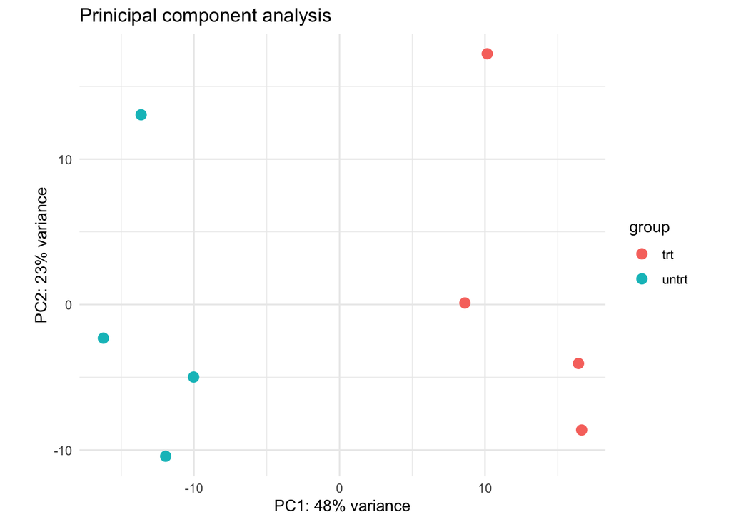

```r
# Transform data for visualization
vsd <- vst(dds, blind = FALSE)

# Plot PCA
plotPCA(vsd, intgroup = "dex") +
  ggtitle("Prinicipal component analysis")
```

# **Step 5:** Differential expression analysis

We are interested in what genes are differentially expressed between the treatment and controls, so we can use the `contrast` parameter to specifically get these results.

```r
# Save results
res <- results(dds,contrast=c("dex","trt","untrt"))

# Summarise the results
summary(res)
```

```
##
## out of 33469 with nonzero total read count
## adjusted p-value < 0.1
## LFC > 0 (up)       : 2604, 7.8%
## LFC < 0 (down)     : 2216, 6.6%
## outliers [1]       : 0, 0%
## low counts [2]     : 15451, 46%
## (mean count < 5)
## [1] see 'cooksCutoff' argument of ?results
## [2] see 'independentFiltering' argument of ?results
```

Note: The DESeq2 vignette recommends pre-filtering which can decrease the size of the file and speed up the analysis. You can read more in the vignette [here](https://bioconductor.org/packages/release/bioc/vignettes/DESeq2/inst/doc/DESeq2.html#pre-filtering).

We can order the results dataframe by p-value.

```r
resOrdered <- res[order(res$pvalue),]
resOrdered
```

```
## log2 fold change (MLE): dex trt vs untrt
## Wald test p-value: dex trt vs untrt
## DataFrame with 63677 rows and 6 columns
##                  baseMean log2FoldChange     lfcSE      stat       pvalue
##                 <numeric>      <numeric> <numeric> <numeric>    <numeric>
## ENSG00000152583   997.440        4.57492  0.184056   24.8561 2.22093e-136
## ENSG00000165995   495.093        3.29106  0.133174   24.7126 7.83941e-135
## ENSG00000120129  3409.029        2.94781  0.121438   24.2743 3.66692e-130
## ENSG00000101347 12703.387        3.76700  0.155438   24.2347 9.58381e-130
## ENSG00000189221  2341.767        3.35358  0.141782   23.6530 1.09895e-123
## ...                   ...            ...       ...       ...          ...
## ENSG00000273481         0             NA        NA        NA           NA
## ENSG00000273482         0             NA        NA        NA           NA
## ENSG00000273484         0             NA        NA        NA           NA
## ENSG00000273490         0             NA        NA        NA           NA
## ENSG00000273491         0             NA        NA        NA           NA
##                         padj
##                    <numeric>
## ENSG00000152583 4.00168e-132
## ENSG00000165995 7.06252e-131
## ENSG00000120129 2.20235e-126
## ENSG00000101347 4.31703e-126
## ENSG00000189221 3.96019e-120
## ...                      ...
## ENSG00000273481           NA
## ENSG00000273482           NA
## ENSG00000273484           NA
## ENSG00000273490           NA
## ENSG00000273491           NA
```

# **Step 6:** Visualise your DE genes with a volcano plot

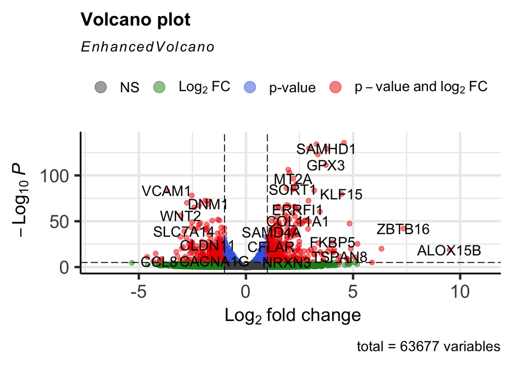

```r
# Add in gene symbols to results
res2 <- cbind(res,rowData(se)[rownames(res),c('gene_id','gene_name')])

# Print volcano plot
EnhancedVolcano(res2,
    lab = res2$gene_name,
    x = 'log2FoldChange',
    y = 'pvalue')
```

If the `cbind()` function does not work, it is likely because you do not have a recent version of `airway` installed that contains the gene name. However, this line is not needed for `EnhancedVolcano()` to work.

# Further reading

Himes BE, Jiang X, Wagner P, Hu R, Wang Q, Klanderman B, Whitaker RM, Duan Q, Lasky-Su J, Nikolos C, Jester W, Johnson M, Panettieri R Jr, Tantisira KG, Weiss ST, Lu Q. ‘RNA-Seq Transcriptome Profiling Identifies CRISPLD2 as a Glucocorticoid Responsive Gene that Modulates Cytokine Function in Airway Smooth Muscle Cells.’ PLoS One. 2014 Jun 13;9(6):e99625. PMID: 24926665. GEO: GSE52778.